# module_3_2 - Visualization Exercise

Keaton Wilson

3/11/2020

## Part 1 - A Visualization Primer - (45 minutes)

Some inspiring figures:  
http://www.r-graph-gallery.com/19-map-leafletr/  
http://www.r-graph-gallery.com/21-distribution-plot-using-ggplot2  
http://www.r-graph-gallery.com/274-map-a-variable-to-ggplot2-scatterplot/  
http://www.r-graph-gallery.com/123-circular-plot-circlize-package-2/

### 1a. Why do visualizations matter? - Small Group Activity

- Take 3 minutes individuals - write down your top 10 reasons why data visualization is important or useful to you?
- Take 5 minutes with your group - compare your notes, come to a group consensus - rank the top 5 reasons from the group.
- Have your *Presenter* write the group’s reasons on the board, and we’ll spend some time discussing.

### 1b. Types of visualization - big thinking about data

#### 1b.1 Small group activity

Within your group - what are all of the types of visualization you can think of. The Conceptor will draw them initially, then I’ll draw them on the board during a speak out.

#### 1b.2 Activity - matching data types to visualization types

Matching activity in group - can you match the visualization to the data type.

File for activity is in the images folder.

### 1c Figure Critique - What makes a good data visualization?

- Small mini-lecture on principles of data visualization and design.
  1. Some resources to build this:
  1. https://www.fusioncharts.com/whitepapers/downloads/Principles-of-Data-Visualization.pdf
  2. https://moz.com/blog/data-visualization-principles-lessons-from-tufte
  3. http://stat.pugetsound.edu/courses/class13/dataVisualization.pdf
  4. http://paldhous.github.io/ucb/2016/dataviz/week2.html

Figures:

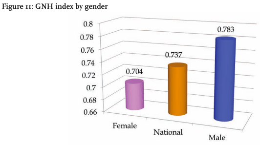

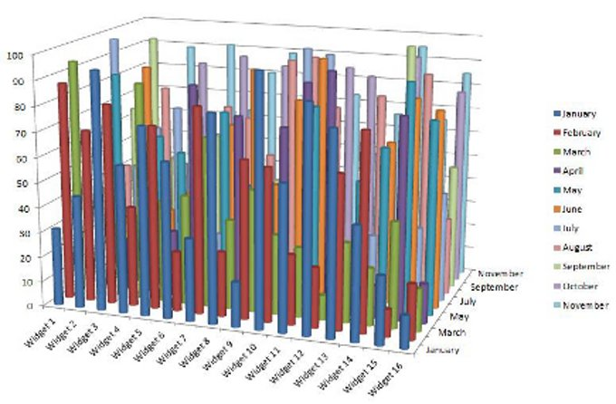

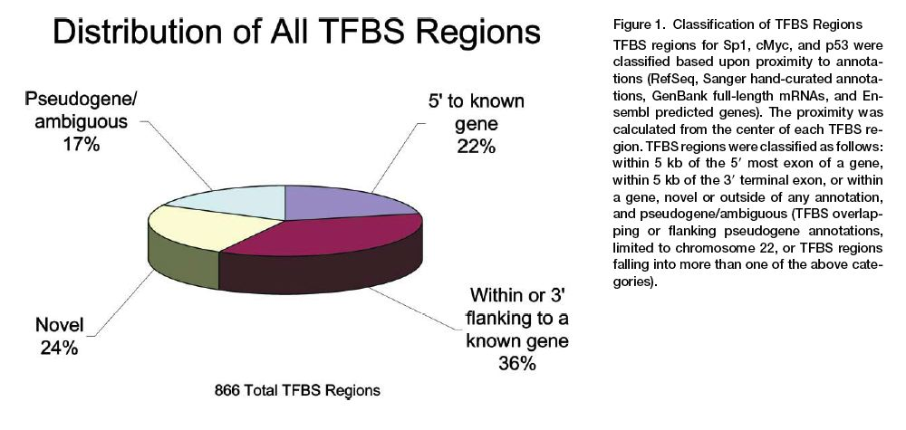

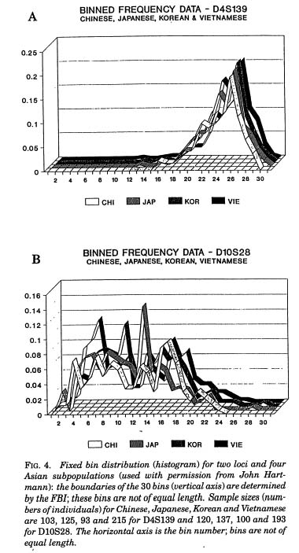

- Students will examine and critique figures from primary literature in their groups. Each group will be passed a figure, students will take 10 minutes to try to interpret the figure, and generate a list of problems. Each group will also draw and present a reimagined version of the figure that is better.